# Freeway Data Report

## Introduction

The Freeway Dataset is for the Federal Highway Administration (FHWA) Test Data Set project submission.

The Portland data environment provides the following data:

1. Freeway data consisting of two months of data from dual-loop detectors deployed in the main line and on-ramps of a Portland-area freeway (I-205)
2. Incident data from the Oregon Department of Transportation Advanced Traffic Management System database and planned event data from the ODOT Trip-Check Traveler Information Portal information web site
3. Weather data from two sources: NOAA data and Remote Weather Information System (RWIS) station data
4. Three types of arterial data:
   1. Volume and occupancy data from four single loop detectors on 82nd Ave
   2. Signal phase and timing data for 32 signals along the 82nd Avenue corridor
   3. Travel times on 82nd Ave., computed from data collected by two Bluetooth readers
5. Transit data provided from TriMet, the Portland-metro area transit agency, including schedule, stop event and passenger counts data for both bus and light rail [1]

[figure not shown]

The data collection period for all datasets is Sept. 15, 2011 through Nov. 15, 2011.

In this report we are trying to show an example of the plots and histograms that can be generated using the datasets and subsets we have. In addition, study the volume in a specific location, which is *Sunnyside NB*, during the peak periods of the day.

## Datasets and Subsets

The main **datasets** that used in this project are:

1. **loops:** it contains 20-second speed, occupancy, volume and data quality flags for the freeway data
2. **detectors:** it contains the detectors’ metadata
3. **stations:** it contains stations’ metadata
4. **highways:** it contains highways’ metadata in the Portland-Vancouver metropolitan region; it focuses on I-205 NB and SB

These four datasets were used to create new **subsets** that needed to perform different operations on the loops:

1. **detectors.N:** It contains the detectors that located in the North side
2. **detectors.S:** It contains the detectors that located in the South side
3. **stations.N:** It contains the stations that located in the North side
4. **stations.S:** It contains the stations that located in the South side
5. **loops.sub:** It contains the detectorid, starttime, volme, and speed columns from loops dataset
6. **loop.1345, loop.1346, loop.1347, loop.1348, and loop.1350:** each contains specific loop’s starttime, volume, and speed data

## Loops’ Volume Summary, Max Speed, and Ave Speed

The loops’ *volume summary, maximum speed, and average speed* computed using subsets that mentioned above. The results can be used to generate different plots and histograms.

**For example:**

This plot shows the volume in loop 1345:

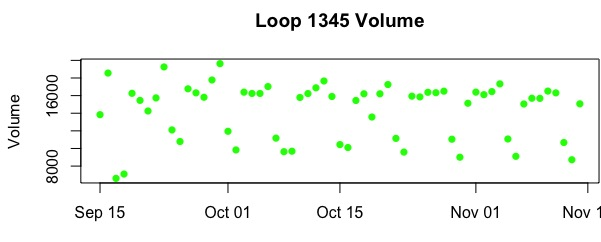

And this histogram represents the frequency of the volume:

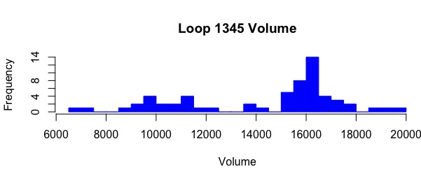

## Finding the Volume in a Specific Location

### Methodology

In order to know all the detectors that located in *Sunnyside NB*, we first need to join loops and detectors data. This can be done by prforming a full join on *detectorid* column that exists in both tables.

The resulted relation can be filtered to get the needed columns only, which are: detectorid, starttime, locationtext, and volume. In order to deal with the time, the starttime column needs to be splitted and stored as a new result.

To get the *Peak Period Volume*, we can use the last result data to get the volume for 7:00am to 9:00am, and for 4:00pm to 6:00pm. Weekday column can be added to get more details that can help with the data.

### Result

The first two plots are for 7:00 am to 9:00 am, and the second two are for 4:00 pm to 6:00 pm.

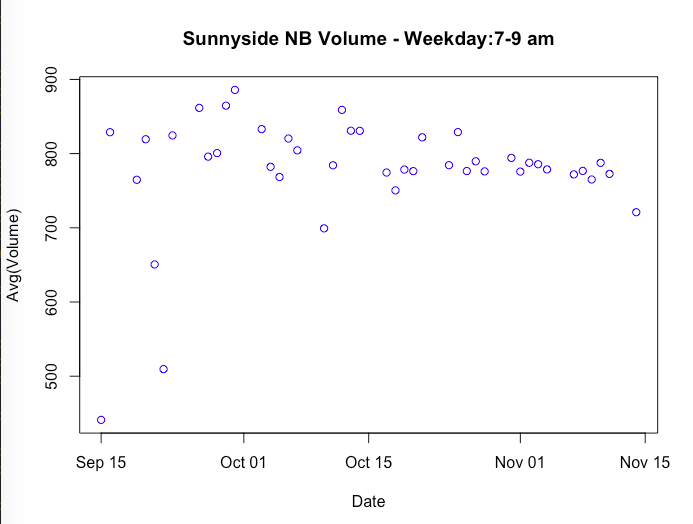

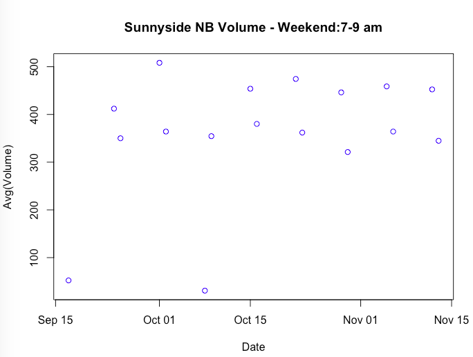

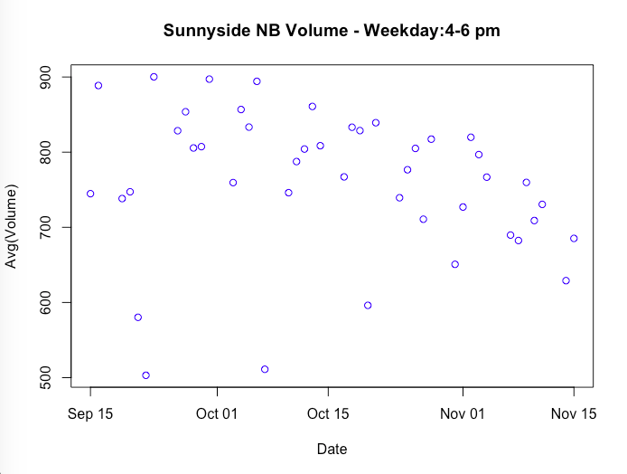

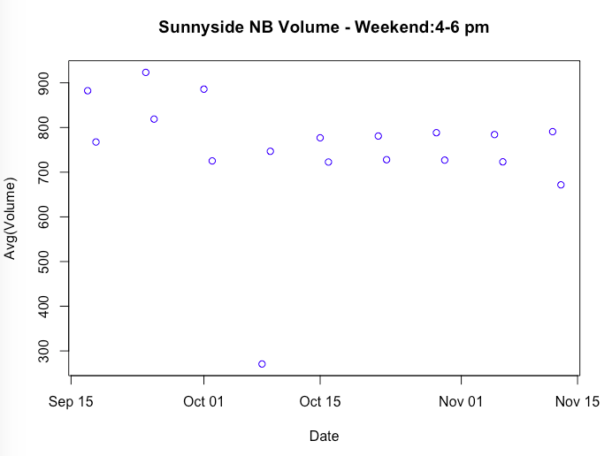

## Finding a Route

*findPathFunction.N* is a function that is implemented to help in finding a path between two stations in the North side.

```r
#FUNCTION
findPathFunction.N <- function(startStation, endStation) {
    path <- startStation

    while(startStation != endStation) {
        for (i in 1:nrow(stations.N))
        {
            if(startStation == stations.N$stationid[i] ) {

                startStation <- stations.N$downstream[i]
                path <- rbind(path, stations.N$downstream[i])

                if(stations.N$downstream[i] == 0) {
                    break
                }
            }
        }
    }
    return(path)
}

#FUNCTION CALL
findPathFunction.N(1045,1140)
findPathFunction.N(1045,1048)
```

[output not shown]

## References

[1] https://www.its-rde.net/data/showds?dataEnvironmentNumber=10002